# Flight Analysis

> Names

Bryce Kickbush, Harrison Roloff, Peter Harmen, Wenpai Shao

> Introduction

Flight, one of man’s greatest inventions has made once treacherous journeys accessible to anyone. Disregarding the 2020 pandemic, more people today are flying than ever, and it is one of the primary sources of domestic travel. This creates a problem that almost all of us have experienced: packed airports. Whether you are at JFK or LAX or even General Mitchel International (MKE), sometimes it is a drag to get on your flight. However less packed flight are less efficient and are thus harmful to the environment. And there is evidence that in recent times there are increasing numbers of low passenger count flight. Using flight data from 2009 and GDP statistics from the year 2017, we can examine cities and their flight patterns. More importantly with this data we can determine if there is a link between the GDP of a city and the number and fullness of flights to that city. [^1]

> Background

Our main form of flight data is from the US Census Bureau. Our relevant variables within the data set are found below. [^2]

| Variable | Description |
| --- | --- |
| Origin City | Origin city name. |
| Destination City | Destination city name |
| Passengers | Number of passengers transported from origin to destination |
| Seats | Number of seats available on flights from origin to destination |

Our other data set we have used is from World Bank national accounts. Our relevant variables are found below. [^3]

| Variable | Description |
| --- | --- |
| County/City | City name. |
| GDP | Cities GDP |

Combining these data sets we have created a data set that we will use to analyze passenger density. We combined these data frames by 1) using delimited functions within Excel to have the city names match the airport (city, ST), then 2) for a join function. Still though, most of the cities were not recognized between the two lists; however, there were enough present to create a meaningful data frame.

| Variable | Description |
| --- | --- |
| Destination City | City name. |
| GDP | Cities GDP |
| flightsTo | Number of flights to destination city |
| totalPassengers | Total passengers travelling to the destination city within a year |
| passengerDensity | Density of passengers on average coming to destination city. |

Factors:

1. A factor that may impact our data is that our GDP is from 2017 and the flights from 2009. Generally the GDP will still be consistent with the GDP of our cities in 2009.
2. We combined two separate data sets containing GDP information and flight information for each city.
3. During the 2008 the travel industry struggled, our data from 2009 may be a bit of an outlier in terms of normal airline traffic.

> Analysis

To start we will make two novel graphs using our data set to take a look at observable trends.

Our GDP vs. Passengers plot shows the massive spike in passengers with some of the highest GDP cities. That being the cities of LA and New York.

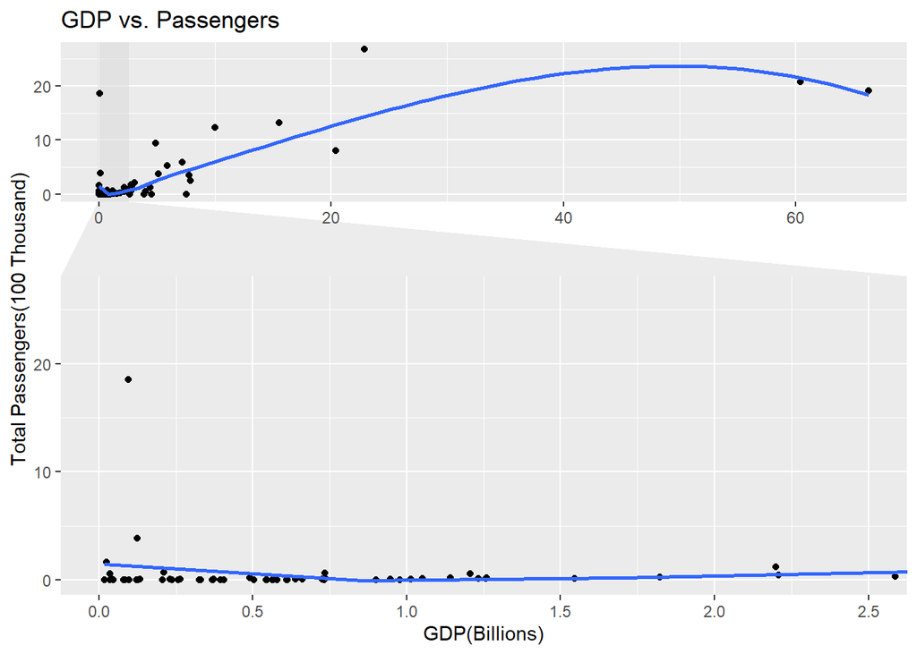

Looking at our plot the passenger density is much higher when the GDP of cities are higher. The more densely packed the plane the better the plane trip is on our environment. Notably most of the passenger counts are clustered in the smaller cities with lower GDP’s. We can see that the larger cities such as New York, Chicago, Los Angeles, have much higher passenger amounts.

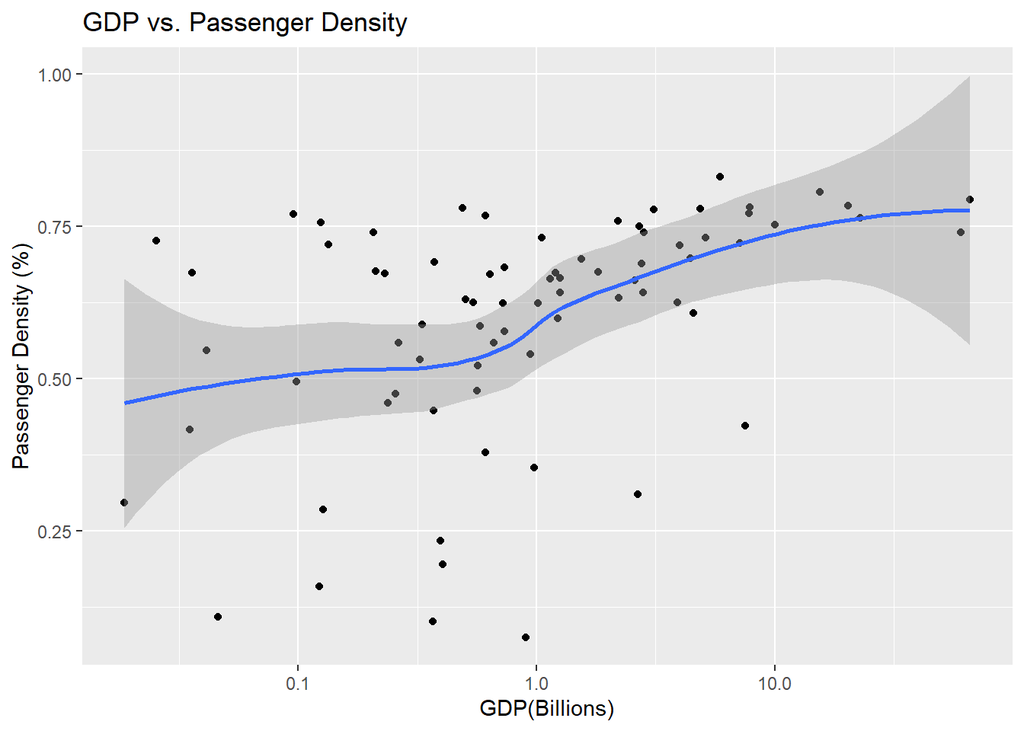

Interpretation: When graphing GDP vs. Passenger Density at a glance it can be seen that density does rise when GDP is higher.

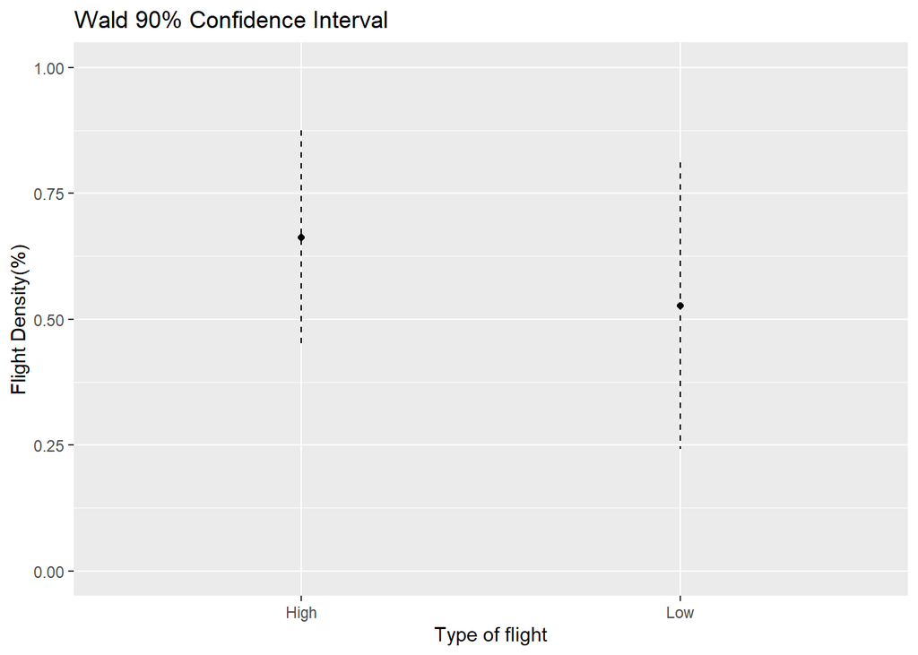

Below we have a two sample t-test to analyze high vs. low density further.

```
##
##  Welch Two Sample t-test
##
## data:  x and y
## t = 3.3627, df = 64.694, p-value = 0.0013
## alternative hypothesis: true difference in means is not equal to 0
## 95 percent confidence interval:
##  0.0550863 0.2162510
## sample estimates:
## mean of x mean of y
## 0.6620102 0.5263415
```

> Regression Analysis

We will test our hypothesis with a regression model of our data and a model of our data residuals.

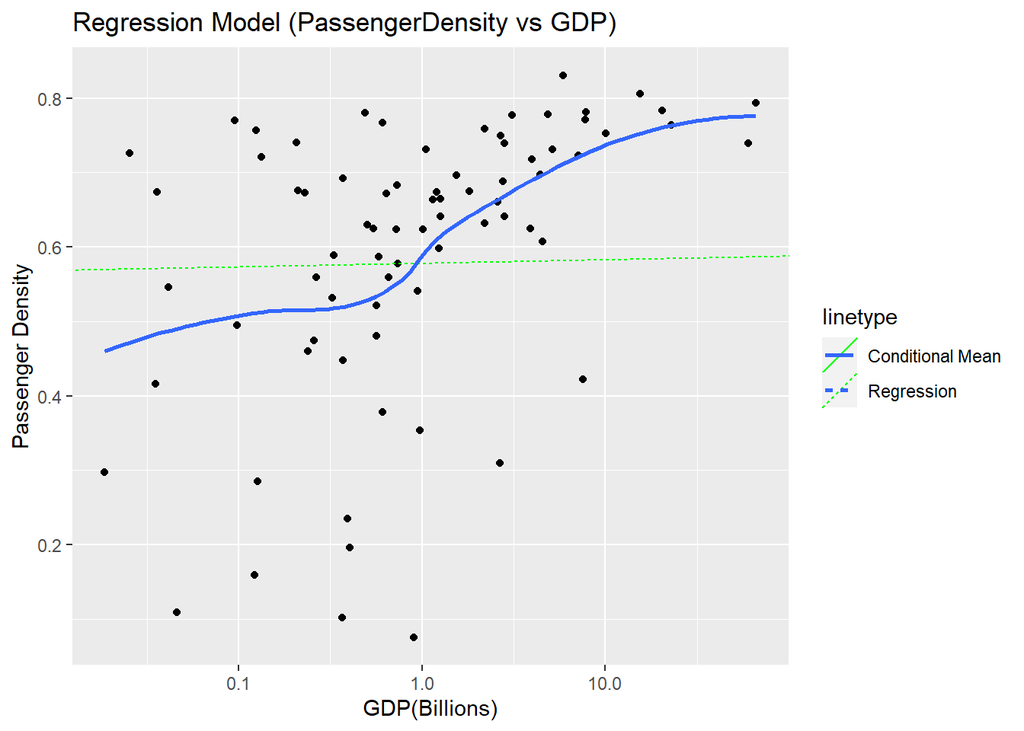

[figure not shown]

> Discussion

Potential issues inherent to our analysis include the mismatch in years between the flight year and GDP year, as the flights we focused on, are from 2009 while the GDP data of those cities is from 2017. This mismatch, depending on how much the city’s GDP changed, could cause certain trends or patterns to be missed. However, this likely won’t lead to too many problems given wealthy cities should still be wealthy a decade later barring larger economic issues. An additional issue is that our focus on a single year could lead to misunderstandings since it disallows us from seeing larger trends and detecting outlying data points. After all, there have been a lot of events in the last few decades that have affected travel trends. Namely, the 2020 COVID-19 pandemic and the 2008 housing crisis and economic recession.

To conclude our in-depth data analysis, we have found that cities with more flights (both inbound and outbound) and higher-density flights in 2009 generally have a higher GDP than those that receive fewer flights, additionally, the flights they do have are generally less full. This is significant because it points towards their being inefficiencies in particular plane flights and which airports these flights typically come from. Furthermore, it gives us an indication that as airports in lower GDP cities have fewer full flights overall, these flights are generally worse for the environment given they are carrying fewer passengers for a given trip compared to a city with a larger GDP leading to the inefficient use of fuel.

> Potential future directions for additional work

In the future we can expand upon our analysis by getting additional data and expanding the overall scope of our search. Our current data was slightly mismatched so getting data on GDP from 2000 to 2009 and making use of a greater proportion of our current flight data could give us a better idea of the interaction between city GDP and number and capacity of flight to that city over a larger and more accurate time frame. Additionally, adding average income of city residents could give a better idea on how the economic status of a city and its residents affects it’s air traffic. A further possibility is that using pollution data of the examined cities could allow for seeing if the pollution trends match that of flight inefficiencies.

> Conclusion

To conclude our data analysis, we have found that cities with more flights (both inbound and outbound) and higher-density flights in 2009 generally have a higher GDP 8 years later. This is significant because it spots trends in the inefficiencies of plane flights and which airports these flights typically come from. Furthermore, it gives us an indication that although airports in lower GDP cities have less flights overall, their flights are typically worse for the environment since they are less densely packed.

> References
[^1]: https://www.cnn.com/travel/article/ghost-flights-pandemic-greenpeace-cmd/index.html
[^2]: https://academictorrents.com/details/a2ccf94bbb4af222bf8e69dad60a68a29f310d9a
[^3]: https://datahub.io/core/gdp